# Project 2 — Linear Models for Next-Day Return Prediction

This project tests whether **linear machine learning models** (OLS, Ridge, Lasso, Elastic Net) can predict **next-day stock returns** better than simple baselines, under a **strict out-of-sample** walk-forward evaluation.

> Key idea: predicting **prices** often looks “too good” because prices are highly persistent. We therefore model **returns**, which better reflect a realistic forecasting task.

```python
import numpy as np
import pandas as pd
import matplotlib.pyplot as plt
import yfinance as yf
plt.style.use("seaborn-v0_8")


from sklearn.linear_model import Ridge, Lasso, ElasticNet
from sklearn.preprocessing import StandardScaler
from sklearn.pipeline import Pipeline
from sklearn.metrics import mean_squared_error, mean_absolute_error

import statsmodels.api as sm

SEED = 42
np.random.seed(SEED)

TARGET_TICKER = "AAPL"
FEATURE_TICKERS = ["AAPL", "AMZN", "MSFT", "QQQ", "^GSPC"]

START_DATE = "2015-01-01"
END_DATE = "2025-01-01"

assert TARGET_TICKER in FEATURE_TICKERS, "TARGET_TICKER must be in FEATURE_TICKERS"
assert START_DATE < END_DATE, "START_DATE must be earlier than END_DATE"

print("Setup OK")
```

```
Setup OK
```

## 1. Problem Statement

### Objective

We evaluate whether linear models can extract predictive signals from historical market data to forecast **next-day returns** of AAPL.

### Why not predict prices?

A model can appear extremely accurate when predicting prices because prices are persistent (tomorrow's price is usually close to today's). This can inflate metrics without providing meaningful predictive value.

### Target definition

We predict the next-day **log return**: $$ y_{t+1} = \log(P_{t+1}) - \log(P_t) $$ All features are constructed using information available at time (t) or earlier.

## 2. Data Acquisition & Cleaning

### Explanation

We download daily **close prices** from Yahoo Finance for a small universe:

- **AAPL** (target)
- AMZN, MSFT (peer stocks)
- QQQ and S&P500 (market proxies)

We align all series on a common calendar and remove missing values before feature construction.

```python
prices = yf.download(
    FEATURE_TICKERS,
    start=START_DATE,
    end=END_DATE,
    progress=False
)["Close"]

prices = prices.dropna()

print("Data OK")
print("Date range:", prices.index.min().date(), "→", prices.index.max().date())
print("Observations:", len(prices))
prices.head()
```

```
Data OK
Date range: 2015-01-02 → 2024-12-31
Observations: 2516
```

| Ticker Date | AAPL | AMZN | MSFT | QQQ | ^GSPC |
| --- | --- | --- | --- | --- | --- |
| 2015-01-02 | 24.214893 | 15.4260 | 39.858456 | 94.784424 | 2058.199951 |
| 2015-01-05 | 23.532721 | 15.1095 | 39.491928 | 93.394066 | 2020.579956 |
| 2015-01-06 | 23.534939 | 14.7645 | 38.912273 | 92.141792 | 2002.609985 |
| 2015-01-07 | 23.864946 | 14.9210 | 39.406693 | 93.329613 | 2025.900024 |
| 2015-01-08 | 24.781891 | 15.0230 | 40.565948 | 95.115913 | 2062.139893 |

```python
prices.isna().sum()
```

```
Ticker
AAPL     0
AMZN     0
MSFT     0
QQQ      0
^GSPC    0
dtype: int64
```

## 3. Feature Engineering

### Explanation

We build a supervised learning dataset where:

- **Target** $y_{t+1}$: next-day log return of AAPL
  $$ y_{t+1} = \log(P_{t+1}) - \log(P_t) $$
- **Features** available at time (t):
  - lagged returns (short-term memory),
  - rolling volatility (risk regime),
  - market proxies returns (broad market information).

All features are constructed so that **no future information** is used.

```python
rets = np.log(prices).diff().dropna()

y = rets[TARGET_TICKER].shift(-1).rename("y")
rets.head()
y.head()
```

```
Date
2015-01-05    0.000094
2015-01-06    0.013925
2015-01-07    0.037702
2015-01-08    0.001072
2015-01-09   -0.024949
Name: y, dtype: float64
```

### Building the feature matrix (X)

We construct a feature matrix using:

- lagged returns for each asset in the universe,
- rolling volatility of AAPL returns,
- rolling mean returns as a simple momentum proxy.

The resulting dataset follows a standard supervised learning structure:

- rows correspond to dates,
- columns correspond to engineered features.

After feature construction, all missing values induced by lagging, rolling windows, and target shifting are removed.

```python
# Feature hyperparameters
LAGS = [1, 2, 3, 5]
VOL_WINDOWS = [5, 10, 20]
MOM_WINDOWS = [5, 10, 20]

print("Feature parameters set")
```

```
Feature parameters set
```

```python
X = pd.DataFrame(index=rets.index)

# 1) Lagged returns for each ticker
for t in FEATURE_TICKERS:
    if t in rets.columns:
        for L in LAGS:
            X[f"{t}_ret_lag{L}"] = rets[t].shift(L)

# 2) Rolling volatility (on target returns)
for w in VOL_WINDOWS:
    X[f"{TARGET_TICKER}_vol_{w}"] = rets[TARGET_TICKER].rolling(w).std()

# 3) Optional: rolling mean (momentum proxy) on target returns
for w in [5, 10, 20]:
    X[f"{TARGET_TICKER}_mom_{w}"] = rets[TARGET_TICKER].rolling(w).mean()

# Align X and y and drop NaNs from feature construction + target shift
data = pd.concat([X, y], axis=1).dropna()
X = data.drop(columns=["y"])
y = data["y"]

print("Feature matrix shape:", X.shape)
print("Target shape:", y.shape)
X.head()
```

```
Feature matrix shape: (2495, 26)
Target shape: (2495,)
```

| Date | AAPL_ret_lag1 | AAPL_ret_lag2 | AAPL_ret_lag3 | AAPL_ret_lag5 | AMZN_ret_lag1 | AMZN_ret_lag2 | AMZN_ret_lag3 | AMZN_ret_lag5 | MSFT_ret_lag1 | MSFT_ret_lag2 | ... | ^GSPC_ret_lag1 | ^GSPC_ret_lag2 | ^GSPC_ret_lag3 | ^GSPC_ret_lag5 | AAPL_vol_5 | AAPL_vol_10 | AAPL_vol_20 | AAPL_mom_5 | AAPL_mom_10 | AAPL_mom_20 |
| --- | --- | --- | --- | --- | --- | --- | --- | --- | --- | --- | --- | --- | --- | --- | --- | --- | --- | --- | --- | --- | --- |
| 2015-02-02 | -0.014742 | 0.030659 | 0.054993 | 0.001061 | 0.128495 | 0.025566 | -0.009301 | -0.008778 | -0.039078 | 0.019712 | ... | -0.013077 | 0.009490 | -0.013588 | 0.002565 | 0.035887 | 0.025232 | 0.023655 | 0.009547 | 0.011266 | 0.004082 |
| 2015-02-03 | 0.012469 | -0.014742 | 0.030659 | -0.035641 | 0.027651 | 0.128495 | 0.025566 | -0.009442 | 0.021549 | -0.039078 | ... | 0.012879 | -0.013077 | 0.009490 | -0.013478 | 0.027115 | 0.024919 | 0.022407 | 0.016709 | 0.008740 | 0.005519 |
| 2015-02-04 | 0.000168 | 0.012469 | -0.014742 | 0.054993 | -0.002527 | 0.027651 | 0.128495 | -0.009301 | 0.007722 | 0.021549 | ... | 0.014336 | 0.012879 | -0.013077 | -0.013588 | 0.016652 | 0.024918 | 0.022374 | 0.007239 | 0.008744 | 0.005896 |
| 2015-02-05 | 0.007641 | 0.000168 | 0.012469 | 0.030659 | 0.003295 | -0.002527 | 0.027651 | 0.025566 | 0.005752 | 0.007722 | ... | -0.004165 | 0.014336 | 0.012879 | 0.009490 | 0.010604 | 0.024197 | 0.022298 | 0.002530 | 0.006887 | 0.005556 |
| 2015-02-06 | 0.007112 | 0.007641 | 0.000168 | -0.014742 | 0.024749 | 0.003295 | -0.002527 | 0.128495 | 0.014474 | 0.005752 | ... | 0.010239 | -0.004165 | 0.014336 | -0.013077 | 0.008128 | 0.024683 | 0.021155 | 0.003787 | 0.005526 | 0.003248 |

5 rows × 26 columns

```python
X.describe().T
```

|  | count | mean | std | min | 25% | 50% | 75% | max |
| --- | --- | --- | --- | --- | --- | --- | --- | --- |
| AAPL_ret_lag1 | 2495.0 | 0.000909 | 0.017883 | -0.137708 | -0.007342 | 0.000988 | 0.010078 | 0.113158 |
| AAPL_ret_lag2 | 2495.0 | 0.000926 | 0.017891 | -0.137708 | -0.007322 | 0.001000 | 0.010091 | 0.113158 |
| AAPL_ret_lag3 | 2495.0 | 0.000947 | 0.017924 | -0.137708 | -0.007322 | 0.001000 | 0.010100 | 0.113158 |
| AAPL_ret_lag5 | 2495.0 | 0.000927 | 0.017937 | -0.137708 | -0.007342 | 0.000988 | 0.010091 | 0.113158 |
| AMZN_ret_lag1 | 2495.0 | 0.001068 | 0.020596 | -0.151398 | -0.008612 | 0.001168 | 0.011244 | 0.132178 |
| AMZN_ret_lag2 | 2495.0 | 0.001084 | 0.020599 | -0.151398 | -0.008600 | 0.001168 | 0.011248 | 0.132178 |
| AMZN_ret_lag3 | 2495.0 | 0.001084 | 0.020599 | -0.151398 | -0.008600 | 0.001168 | 0.011248 | 0.132178 |
| AMZN_ret_lag5 | 2495.0 | 0.001069 | 0.020599 | -0.151398 | -0.008629 | 0.001168 | 0.011244 | 0.132178 |
| MSFT_ret_lag1 | 2495.0 | 0.000994 | 0.016990 | -0.159453 | -0.006631 | 0.000978 | 0.009721 | 0.132929 |
| MSFT_ret_lag2 | 2495.0 | 0.001009 | 0.016990 | -0.159453 | -0.006626 | 0.000982 | 0.009747 | 0.132929 |
| MSFT_ret_lag3 | 2495.0 | 0.000996 | 0.017006 | -0.159453 | -0.006631 | 0.000982 | 0.009747 | 0.132929 |
| MSFT_ret_lag5 | 2495.0 | 0.000953 | 0.017118 | -0.159453 | -0.006641 | 0.000978 | 0.009747 | 0.132929 |
| QQQ_ret_lag1 | 2495.0 | 0.000686 | 0.013794 | -0.127592 | -0.005008 | 0.001209 | 0.007804 | 0.081309 |
| QQQ_ret_lag2 | 2495.0 | 0.000696 | 0.013792 | -0.127592 | -0.005000 | 0.001213 | 0.007822 | 0.081309 |
| QQQ_ret_lag3 | 2495.0 | 0.000694 | 0.013792 | -0.127592 | -0.005008 | 0.001213 | 0.007822 | 0.081309 |
| QQQ_ret_lag5 | 2495.0 | 0.000673 | 0.013799 | -0.127592 | -0.005024 | 0.001198 | 0.007786 | 0.081309 |
| ^GSPC_ret_lag1 | 2495.0 | 0.000434 | 0.011275 | -0.127652 | -0.003759 | 0.000648 | 0.005739 | 0.089683 |
| ^GSPC_ret_lag2 | 2495.0 | 0.000442 | 0.011274 | -0.127652 | -0.003752 | 0.000672 | 0.005741 | 0.089683 |
| ^GSPC_ret_lag3 | 2495.0 | 0.000437 | 0.011278 | -0.127652 | -0.003759 | 0.000672 | 0.005741 | 0.089683 |
| ^GSPC_ret_lag5 | 2495.0 | 0.000425 | 0.011279 | -0.127652 | -0.003762 | 0.000648 | 0.005735 | 0.089683 |
| AAPL_vol_5 | 2495.0 | 0.015229 | 0.009945 | 0.001389 | 0.008496 | 0.012787 | 0.019005 | 0.108266 |
| AAPL_vol_10 | 2495.0 | 0.015827 | 0.008640 | 0.003588 | 0.010186 | 0.013957 | 0.019337 | 0.080839 |
| AAPL_vol_20 | 2495.0 | 0.016254 | 0.007658 | 0.004805 | 0.011240 | 0.014660 | 0.019147 | 0.068108 |
| AAPL_mom_5 | 2495.0 | 0.000924 | 0.007470 | -0.038549 | -0.003254 | 0.001318 | 0.005362 | 0.033804 |
| AAPL_mom_10 | 2495.0 | 0.000929 | 0.005333 | -0.023176 | -0.002224 | 0.001379 | 0.004385 | 0.020441 |
| AAPL_mom_20 | 2495.0 | 0.000928 | 0.003882 | -0.015580 | -0.001317 | 0.001183 | 0.003711 | 0.014831 |

### Visual checks

We include a few simple plots to understand the engineered dataset:

- distribution of target returns,
- rolling volatility over time,
- correlation structure across features (to anticipate multicollinearity).

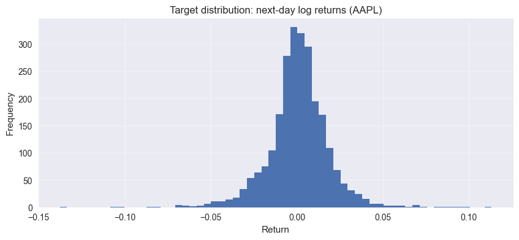

```python
plt.figure(figsize=(10,4))
plt.hist(y, bins=60)
plt.title("Target distribution: next-day log returns (AAPL)")
plt.xlabel("Return")
plt.ylabel("Frequency")
plt.grid(True, alpha=0.3)
plt.show()
```

The target distribution is centered around zero and exhibits heavy tails, as expected for daily equity returns. This highlights the intrinsic difficulty of short-horizon return prediction.

```python
import os

os.makedirs("reports/figures", exist_ok=True)

plt.savefig("reports/figures/target_return_distribution.png", dpi=150, bbox_inches="tight")
```

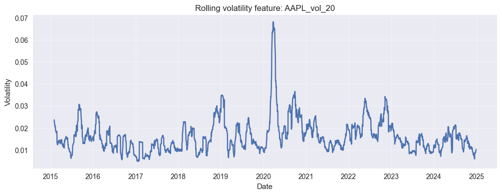

```python
vol_col = f"{TARGET_TICKER}_vol_{VOL_WINDOWS[-1]}"
plt.figure(figsize=(12,4))
plt.plot(data.index, data[vol_col])
plt.title(f"Rolling volatility feature: {vol_col}")
plt.xlabel("Date")
plt.ylabel("Volatility")
plt.grid(True, alpha=0.3)
plt.show()
```

The rolling volatility exhibits clear regime changes over time, with pronounced spikes during periods of market stress (e.g., 2020). This supports the inclusion of volatility-based features in the predictive model.

```python
import os

os.makedirs("reports/figures", exist_ok=True)

plt.savefig(
    "reports/figures/rolling_volatility_20d.png",
    dpi=150,
    bbox_inches="tight"
)
```

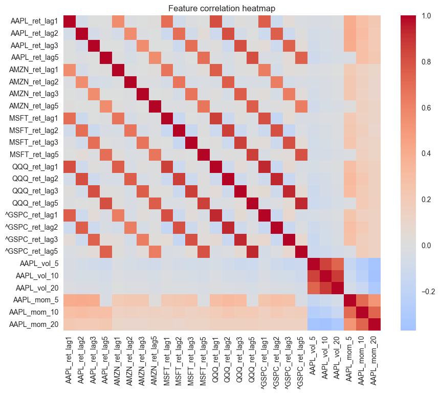

```python
import seaborn as sns

corr = X.corr()
plt.figure(figsize=(10,8))
sns.heatmap(corr, cmap="coolwarm", center=0)
plt.title("Feature correlation heatmap")
plt.show()
```

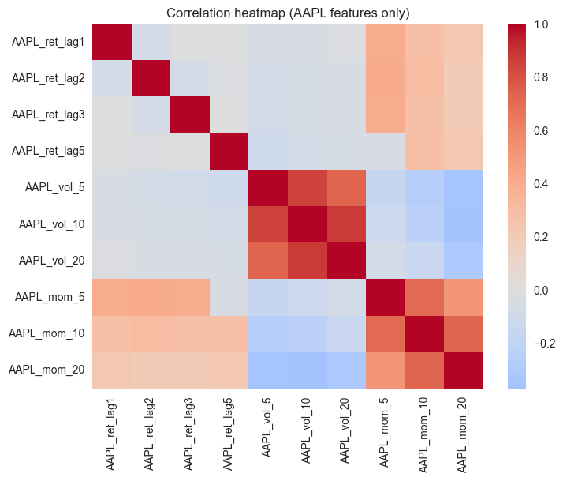

```python
aapl_cols = [c for c in X.columns if c.startswith("AAPL")]
corr_aapl = X[aapl_cols].corr()

plt.figure(figsize=(8,6))
sns.heatmap(corr_aapl, cmap="coolwarm", center=0)
plt.title("Correlation heatmap (AAPL features only)")
plt.show()
```

```python
import os

os.makedirs("reports/figures", exist_ok=True)

plt.savefig(
    "reports/figures/corr_aapl_features.png",
    dpi=150,
    bbox_inches="tight"
)
```

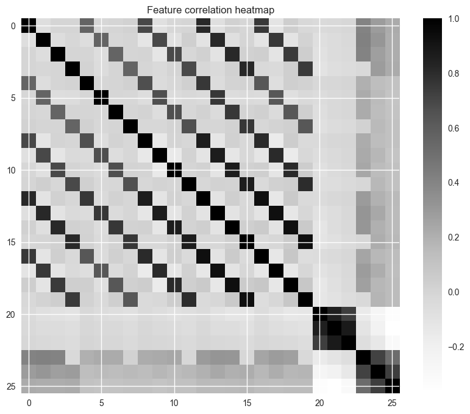

```python
corr = X.corr().values
plt.figure(figsize=(10,8))
plt.imshow(corr, aspect="auto")
plt.title("Feature correlation heatmap")
plt.colorbar()
plt.show()
```

Based on these diagnostics, the feature set exhibits expected levels of multicollinearity, motivating the use of regularized linear models in the subsequent analysis.

## 4. Baseline Models (Benchmarks)

Before evaluating machine learning models, we define **simple baseline predictors** to establish meaningful reference points.

A predictive model is only useful if it outperforms these naive alternatives.

### Baseline definitions

We consider the following baselines:

1. **Zero-return baseline**  
   Always predicts a return of zero.  
   This corresponds to a "no-signal" strategy.
2. **Last-return baseline**  
   Predicts tomorrow's return as today's return.  
   This is a simple persistence / random-walk assumption.

These baselines provide lower bounds on predictive performance and help assess whether more complex models add genuine value beyond naive assumptions.

```python
# Baseline 1: zero return
y_pred_zero = pd.Series(0.0, index=y.index, name="zero_return")

# Baseline 2: last observed return (persistence)
y_pred_last = rets[TARGET_TICKER].shift(1).loc[y.index]
y_pred_last.name = "last_return"

y_pred_zero.head(), y_pred_last.head()
```

```
(Date
 2015-02-02    0.0
 2015-02-03    0.0
 2015-02-04    0.0
 2015-02-05    0.0
 2015-02-06    0.0
 Name: zero_return, dtype: float64,
 Date
 2015-02-02   -0.014742
 2015-02-03    0.012469
 2015-02-04    0.000168
 2015-02-05    0.007641
 2015-02-06    0.007112
 Name: last_return, dtype: float64)
```

```python
baseline_preds = pd.DataFrame({
    "y_true": y,
    "zero_return": y_pred_zero,
    "last_return": y_pred_last
})
```

### Evaluation metrics

We evaluate predictive performance using standard regression metrics:

- **Root Mean Squared Error (RMSE)**
  $$ \mathrm{RMSE} = \sqrt{\frac{1}{T}\sum_{t=1}^{T} (y_t - \hat{y}_t)^2} $$
- **Mean Absolute Error (MAE)**
  $$ \mathrm{MAE} = \frac{1}{T}\sum_{t=1}^{T} |y_t - \hat{y}_t| $$

In addition, we report a **Directional Accuracy** metric, defined as the fraction of times the predicted return has the same sign as the realized return:

$$ \mathrm{DA} = \frac{1}{|\mathcal{T}|}\sum_{t \in \mathcal{T}} \mathbf{1}\big(\mathrm{sign}(y_t) = \mathrm{sign}(\hat{y}_t)\big) $$

where $$\mathcal{T} = \{ t : |y_t| > \varepsilon \}$$ excludes observations with near-zero realized returns (to avoid ambiguous sign comparisons).

```python
def directional_accuracy(y_true, y_pred, tol=1e-6):
    mask = np.abs(y_true) > tol
    return np.mean(
        np.sign(y_true[mask]) == np.sign(y_pred[mask])
    )


def regression_metrics(y_true, y_pred):
    return {
        "RMSE": np.sqrt(mean_squared_error(y_true, y_pred)),
        "MAE": mean_absolute_error(y_true, y_pred),
        "Directional Accuracy": directional_accuracy(y_true, y_pred),
    }
```

```python
baseline_results = pd.DataFrame.from_dict(
    {
        "Zero Return": regression_metrics(y, y_pred_zero),
        "Last Return": regression_metrics(y, y_pred_last),
    },
    orient="index"
)

baseline_results
```

|  | RMSE | MAE | Directional Accuracy |
| --- | --- | --- | --- |
| Zero Return | 0.017901 | 0.012502 | 0.000000 |
| Last Return | 0.025313 | 0.018206 | 0.496183 |

As expected, both baseline models exhibit limited predictive performance. The zero-return baseline reflects a no-signal strategy, while the last-return baseline captures simple return persistence. Any machine learning model must outperform these benchmarks to be considered economically meaningful.

```python
import os

os.makedirs("reports/tables", exist_ok=True)
baseline_results.to_csv("reports/tables/baseline_results.csv")
```

### Baseline behavior visualization

We visualize baseline predictions against realized returns over a short time window to understand their behavior.

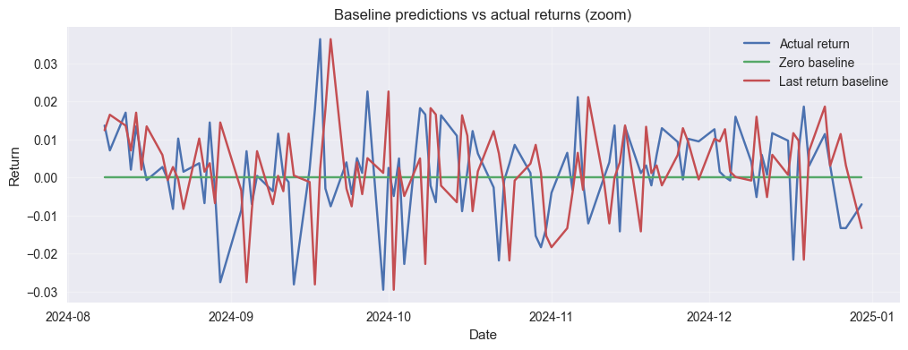

```python
window = 100  # number of days to visualize

plt.figure(figsize=(12,4))
plt.plot(y.index[-window:], y.values[-window:], label="Actual return")
plt.plot(y.index[-window:], y_pred_zero.values[-window:], label="Zero baseline")
plt.plot(y.index[-window:], y_pred_last.values[-window:], label="Last return baseline")
plt.title("Baseline predictions vs actual returns (zoom)")
plt.xlabel("Date")
plt.ylabel("Return")
plt.legend()
plt.grid(True, alpha=0.3)
plt.show()
```

### Interpretation

These baselines highlight the difficulty of short-horizon return prediction:

- predicting zero often yields surprisingly competitive error metrics,
- persistence captures short-term autocorrelation but is unstable.

Any machine learning model must **consistently outperform these baselines** to be considered useful.

These visual diagnostics reinforce the need for robust out-of-sample evaluation, as apparent short-term alignment can easily arise from noise.

```python
import os
os.makedirs("reports/figures", exist_ok=True)

plt.savefig(
    "reports/figures/baseline_behavior_zoom.png",
    dpi=150,
    bbox_inches="tight"
)
```

## 5. Linear Models

In this section, we investigate whether **linear predictive models** can extract useful information from engineered features to forecast **next-day stock returns**.

Linear models are studied for three main reasons:

- they are mathematically well understood,
- they provide interpretable coefficients,
- their limitations are well documented in financial time series, making them ideal diagnostic tools.

### Linear regression framework

We consider the standard linear regression model:

$$ y_t = \beta_0 + \sum_{j=1}^{p} \beta_j x_{t,j} + \varepsilon_t $$

where:

- $y_t$ is the target variable (next-day return),
- $x_{t,j}$ are features available at time $t$,
- $\beta_j$ are regression coefficients,
- $\varepsilon_t$ is a noise term.

The goal is to estimate the coefficient vector $\boldsymbol{\beta} = (\beta_0, \beta_1, \dots, \beta_p)$ that best explains the relationship between features and returns.

### Ordinary Least Squares (OLS)

The **Ordinary Least Squares (OLS)** estimator minimizes the sum of squared residuals:

$$ \hat{\boldsymbol{\beta}}^{\text{OLS}} = \arg\min_{\boldsymbol{\beta}} \sum_{t=1}^{T} \left( y_t - \beta_0 - \sum_{j=1}^{p} \beta_j x_{t,j} \right)^2 $$

In matrix form, when $X^\top X$ is invertible:

$$ \hat{\boldsymbol{\beta}}^{\text{OLS}} = (X^\top X)^{-1} X^\top y $$

Although optimal under strong assumptions, OLS often performs poorly in financial prediction due to multicollinearity, low signal-to-noise ratio, and parameter instability.

### Regularization and bias–variance tradeoff

To stabilize coefficient estimates, we introduce **regularization**, which penalizes large coefficients and controls model complexity.

Regularization intentionally introduces bias to reduce variance, a central concept in the **bias–variance tradeoff**.

### Ridge Regression (L2 penalty)

Ridge regression solves:

$$ \hat{\boldsymbol{\beta}}^{\text{Ridge}} = \arg\min_{\boldsymbol{\beta}} \left[ \sum_{t=1}^{T} \left( y_t - \beta_0 - \sum_{j=1}^{p} \beta_j x_{t,j} \right)^2 + \lambda \sum_{j=1}^{p} \beta_j^2 \right] $$

where $\lambda \ge 0$ controls the strength of regularization.

Ridge regression shrinks coefficients toward zero, reducing variance but keeping all predictors in the model.

### Lasso Regression (L1 penalty)

Lasso regression introduces an L1 penalty:

$$ \hat{\boldsymbol{\beta}}^{\text{Lasso}} = \arg\min_{\boldsymbol{\beta}} \left[ \sum_{t=1}^{T} \left( y_t - \beta_0 - \sum_{j=1}^{p} \beta_j x_{t,j} \right)^2 + \lambda \sum_{j=1}^{p} |\beta_j| \right] $$

Lasso encourages sparse solutions and can set some coefficients exactly to zero, performing implicit feature selection.

### Elastic Net (L1 + L2 penalty)

Elastic Net combines both penalties:

$$ \hat{\boldsymbol{\beta}}^{\text{EN}} = \arg\min_{\boldsymbol{\beta}} \left[ \sum_{t=1}^{T} \left( y_t - \beta_0 - \sum_{j=1}^{p} \beta_j x_{t,j} \right)^2 + \lambda \left( \alpha \sum_{j=1}^{p} |\beta_j| + (1-\alpha) \sum_{j=1}^{p} \beta_j^2 \right) \right] $$

where $\alpha \in [0,1]$ controls the balance between L1 and L2 penalties.

Elastic Net is particularly well suited to settings with correlated predictors.

### Roadmap for implementation

In the following subsections, we:

- implement each model using standardized features,
- evaluate them under a walk-forward framework,
- compare their performance to baseline benchmarks.

We start with OLS as a reference model, before introducing regularization.

### 5.1 Ordinary Least Squares (OLS)

We start with OLS as a reference linear model. The objective is not performance optimization, but to understand coefficient behavior, prediction noise, and residual structure in a low signal-to-noise setting.

```python
# Add intercept
X_ols = sm.add_constant(X)

# Sanity checks
assert X_ols.isna().sum().sum() == 0
assert y.isna().sum() == 0

print("Design matrix shape:", X_ols.shape)
print("Target shape:", y.shape)

# Fit OLS
ols_model = sm.OLS(y, X_ols).fit()

# Statistical summary (for reference)
ols_model.summary()
```

```
Design matrix shape: (2495, 27)
Target shape: (2495,)
```

OLS Regression Results

| Dep. Variable: | y | R-squared: | 0.027 |
| --- | --- | --- | --- |
| Model: | OLS | Adj. R-squared: | 0.017 |
| Method: | Least Squares | F-statistic: | 2.657 |
| Date: | Tue, 10 Feb 2026 | Prob (F-statistic): | 1.11e-05 |
| Time: | 21:34:14 | Log-Likelihood: | 6534.4 |
| No. Observations: | 2495 | AIC: | -1.301e+04 |
| Df Residuals: | 2468 | BIC: | -1.286e+04 |
| Df Model: | 26 |  |  |
| Covariance Type: | nonrobust |  |  |

|  | coef | std err | t | P>\|t\| | [0.025 | 0.975] |
| --- | --- | --- | --- | --- | --- | --- |
| const | 0.0012 | 0.001 | 1.314 | 0.189 | -0.001 | 0.003 |
| AAPL_ret_lag1 | -0.0175 | 0.038 | -0.461 | 0.645 | -0.092 | 0.057 |
| AAPL_ret_lag2 | -0.0158 | 0.037 | -0.422 | 0.673 | -0.089 | 0.058 |
| AAPL_ret_lag3 | 0.0308 | 0.038 | 0.815 | 0.415 | -0.043 | 0.105 |
| AAPL_ret_lag5 | 0.0532 | 0.037 | 1.449 | 0.147 | -0.019 | 0.125 |
| AMZN_ret_lag1 | -0.0095 | 0.028 | -0.337 | 0.736 | -0.065 | 0.046 |
| AMZN_ret_lag2 | -0.0015 | 0.028 | -0.053 | 0.957 | -0.057 | 0.054 |
| AMZN_ret_lag3 | 0.0324 | 0.028 | 1.154 | 0.249 | -0.023 | 0.088 |
| AMZN_ret_lag5 | 0.0265 | 0.028 | 0.945 | 0.345 | -0.029 | 0.082 |
| MSFT_ret_lag1 | -0.1126 | 0.042 | -2.672 | 0.008 | -0.195 | -0.030 |
| MSFT_ret_lag2 | 0.1221 | 0.042 | 2.878 | 0.004 | 0.039 | 0.205 |
| MSFT_ret_lag3 | 0.0421 | 0.042 | 1.002 | 0.316 | -0.040 | 0.124 |
| MSFT_ret_lag5 | -0.0391 | 0.042 | -0.942 | 0.346 | -0.121 | 0.042 |
| QQQ_ret_lag1 | 0.0197 | 0.110 | 0.179 | 0.858 | -0.196 | 0.235 |
| QQQ_ret_lag2 | -0.1579 | 0.110 | -1.431 | 0.152 | -0.374 | 0.058 |
| QQQ_ret_lag3 | -0.0145 | 0.110 | -0.131 | 0.896 | -0.231 | 0.202 |
| QQQ_ret_lag5 | -0.0318 | 0.110 | -0.290 | 0.772 | -0.247 | 0.183 |
| ^GSPC_ret_lag1 | 0.2208 | 0.091 | 2.428 | 0.015 | 0.042 | 0.399 |
| ^GSPC_ret_lag2 | 0.0661 | 0.091 | 0.722 | 0.470 | -0.113 | 0.245 |
| ^GSPC_ret_lag3 | -0.1287 | 0.091 | -1.408 | 0.159 | -0.308 | 0.051 |
| ^GSPC_ret_lag5 | -0.1452 | 0.091 | -1.600 | 0.110 | -0.323 | 0.033 |
| AAPL_vol_5 | -0.1693 | 0.071 | -2.396 | 0.017 | -0.308 | -0.031 |
| AAPL_vol_10 | 0.0579 | 0.114 | 0.509 | 0.611 | -0.165 | 0.281 |
| AAPL_vol_20 | 0.0839 | 0.097 | 0.864 | 0.387 | -0.106 | 0.274 |
| AAPL_mom_5 | -0.1618 | 0.090 | -1.788 | 0.074 | -0.339 | 0.016 |
| AAPL_mom_10 | 0.0308 | 0.128 | 0.241 | 0.810 | -0.220 | 0.282 |
| AAPL_mom_20 | 0.1388 | 0.141 | 0.986 | 0.324 | -0.137 | 0.415 |

| Omnibus: | 267.545 | Durbin-Watson: | 2.061 |
| --- | --- | --- | --- |
| Prob(Omnibus): | 0.000 | Jarque-Bera (JB): | 2042.535 |
| Skew: | -0.176 | Prob(JB): | 0.00 |
| Kurtosis: | 7.419 | Cond. No. | 476. |

Notes:  
[1] Standard Errors assume that the covariance matrix of the errors is correctly specified.

OLS results are reported in-sample for diagnostic purposes only. Out-of-sample evaluation is performed in the next section using a walk-forward framework.

```python
ols_coefs = ols_model.params
ols_coefs.sort_values(key=np.abs, ascending=False).head(10)
```

```
^GSPC_ret_lag1    0.220791
AAPL_vol_5       -0.169264
AAPL_mom_5       -0.161827
QQQ_ret_lag2     -0.157869
^GSPC_ret_lag5   -0.145184
AAPL_mom_20       0.138832
^GSPC_ret_lag3   -0.128744
MSFT_ret_lag2     0.122064
MSFT_ret_lag1    -0.112585
AAPL_vol_20       0.083910
dtype: float64
```

Overall, OLS confirms the presence of weak and unstable linear signals in daily returns. This motivates the use of regularized linear models evaluated under strict out-of-sample conditions.

```
Top 10 coefficients by absolute value:
```

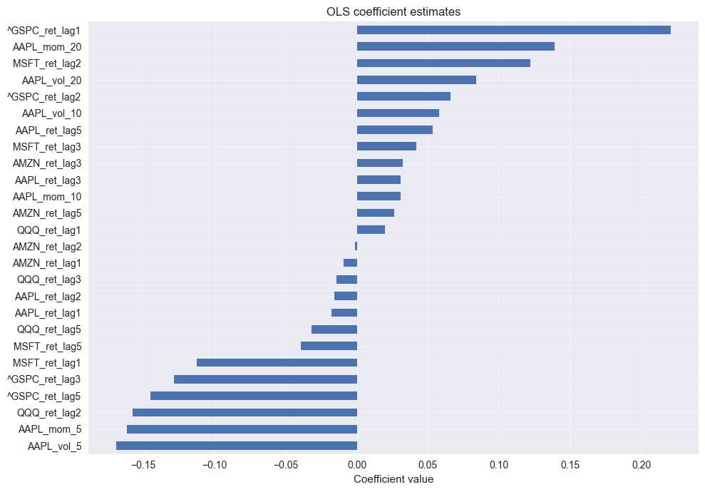

```python
coef = ols_model.params.drop("const")

# Sort coefficients
coef_sorted = coef.sort_values()
coef_abs = coef.abs().sort_values(ascending=False)

print("Top 10 coefficients by absolute value:")
coef_abs.head(10)

# Bar plot of coefficients
plt.figure(figsize=(10,7))
coef_sorted.plot(kind="barh")
plt.title("OLS coefficient estimates")
plt.xlabel("Coefficient value")
plt.grid(True, alpha=0.3)
plt.tight_layout()
plt.show()
```

Note: coefficients are estimated on non-standardized features. As a result, their magnitudes are not directly comparable and should be interpreted purely as a diagnostic of instability rather than as economically meaningful effects.

```python
y_pred_ols = pd.Series(
    ols_model.predict(X_ols),
    index=y.index,
    name="OLS prediction"
)

pd.DataFrame({
    "Actual": y,
    "OLS prediction": y_pred_ols
}).describe()
```

|  | Actual | OLS prediction |
| --- | --- | --- |
| count | 2495.000000 | 2495.000000 |
| mean | 0.000901 | 0.000901 |
| std | 0.017882 | 0.002951 |
| min | -0.137708 | -0.016561 |
| 25% | -0.007342 | -0.000704 |
| 50% | 0.000952 | 0.000954 |
| 75% | 0.010063 | 0.002564 |
| max | 0.113158 | 0.025996 |

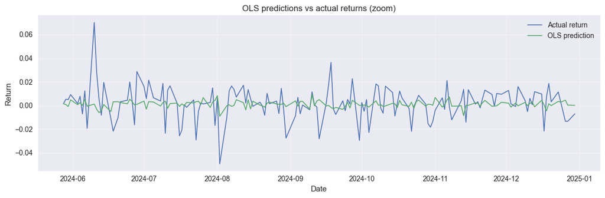

```python
window = 150

plt.figure(figsize=(12,4))
plt.plot(y.index[-window:], y.values[-window:], label="Actual return", linewidth=1.2)
plt.plot(y.index[-window:], y_pred_ols.values[-window:], label="OLS prediction", linewidth=1.2)
plt.title("OLS predictions vs actual returns (zoom)")
plt.xlabel("Date")
plt.ylabel("Return")
plt.legend()
plt.grid(True, alpha=0.3)
plt.tight_layout()
plt.show()
```

As expected, OLS predictions exhibit strong variance shrinkage and fail to capture large return realizations, reflecting the low signal-to-noise ratio of daily returns.

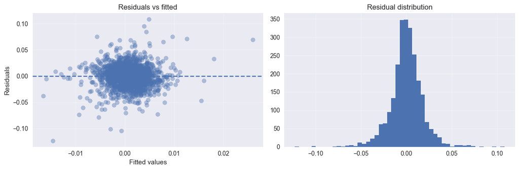

```python
residuals = y - y_pred_ols

fig, axes = plt.subplots(1, 2, figsize=(12,4))

# Residuals vs fitted
axes[0].scatter(y_pred_ols, residuals, alpha=0.4)
axes[0].axhline(0, linestyle="--")
axes[0].set_title("Residuals vs fitted")
axes[0].set_xlabel("Fitted values")
axes[0].set_ylabel("Residuals")
axes[0].grid(True, alpha=0.3)

# Residual distribution
axes[1].hist(residuals, bins=50)
axes[1].set_title("Residual distribution")
axes[1].grid(True, alpha=0.3)

plt.tight_layout()
plt.show()
```

### Comments and interpretation

Several observations can be made from the OLS results:

- Coefficient estimates are highly sensitive to the feature set, with large magnitudes appearing for correlated predictors.
- Predicted returns fluctuate around zero and show weak co-movement with realized returns.
- Residual variance remains large and exhibits no clear structure, indicating a low signal-to-noise regime.

Overall, OLS struggles to produce stable and informative predictions in this setting. These results are consistent with the well-known limitations of unregularized linear models in financial return prediction.

This motivates the introduction of **regularization**, which explicitly controls model complexity and improves coefficient stability.

```python
from pathlib import Path

FIG_DIR = Path("reports/figures")
TAB_DIR = Path("reports/tables")
FIG_DIR.mkdir(parents=True, exist_ok=True)
TAB_DIR.mkdir(parents=True, exist_ok=True)

def savefig(name: str, dpi: int = 150):

    plt.savefig(FIG_DIR / name, dpi=dpi, bbox_inches="tight")
```

```python
ols_params = ols_model.params
ols_params.to_csv(TAB_DIR / "ols_params.csv")
```

```python
ols_top_abs = ols_model.params.drop("const").abs().sort_values(ascending=False).head(20)
ols_top_abs.to_csv(TAB_DIR / "ols_top20_abs.csv")
```

```python
with open(TAB_DIR / "ols_summary.txt", "w", encoding="utf-8") as f:
    f.write(ols_model.summary().as_text())
```

```python
savefig("ols_coefficients_barh.png")
```

```python
savefig("ols_predictions_vs_actual_zoom.png")
```

```python
savefig("ols_residuals_diagnostics.png")
```

### 5.2 Ridge Regression

We now introduce **Ridge regression**, which adds an L2 penalty to the OLS objective. The goal is to stabilize coefficient estimates and reduce variance in the presence of noisy and correlated predictors.

```python
from sklearn.linear_model import Ridge
from sklearn.preprocessing import StandardScaler
from sklearn.pipeline import Pipeline

# Ridge regularization strength
ridge_alpha = 1.0

# Pipeline: standardization + ridge
ridge_model = Pipeline([
    ("scaler", StandardScaler()),
    ("ridge", Ridge(alpha=ridge_alpha))
])

# Fit Ridge model
ridge_model.fit(X, y)

# In-sample predictions
y_pred_ridge = pd.Series(
    ridge_model.predict(X),
    index=y.index,
    name="Ridge prediction"
)

print("Ridge model fitted with alpha =", ridge_alpha)
```

```
Ridge model fitted with alpha = 1.0
```

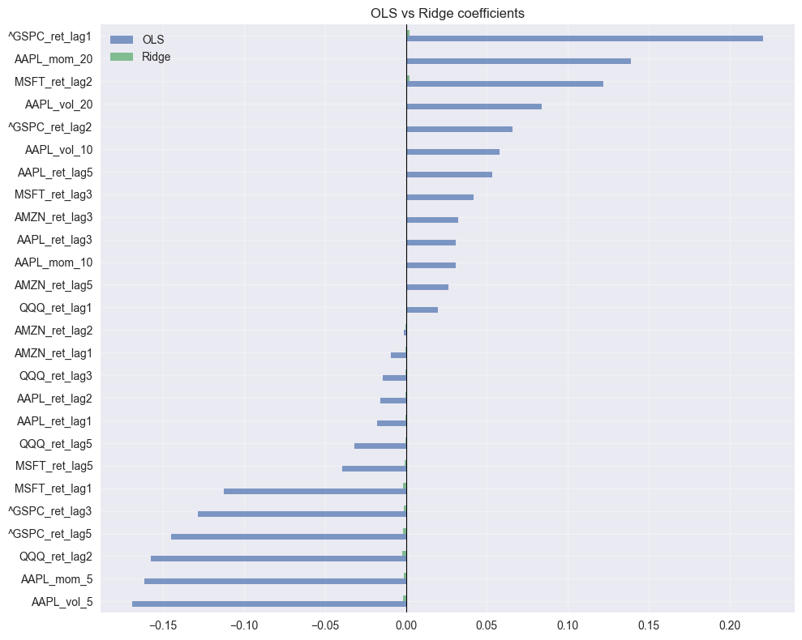

```python
ridge_coefs = pd.Series(
    ridge_model.named_steps["ridge"].coef_,
    index=X.columns
)

coef_compare = pd.DataFrame({
    "OLS": coef,
    "Ridge": ridge_coefs
})

coef_compare.sort_values("OLS").plot(
    kind="barh",
    figsize=(10,8),
    alpha=0.7
)
plt.title("OLS vs Ridge coefficients")
plt.axvline(0, color="black", linewidth=0.8)
plt.grid(True, alpha=0.3)
plt.tight_layout()
plt.savefig("ols_vs_ridge_coefficients.png")
plt.show()
```

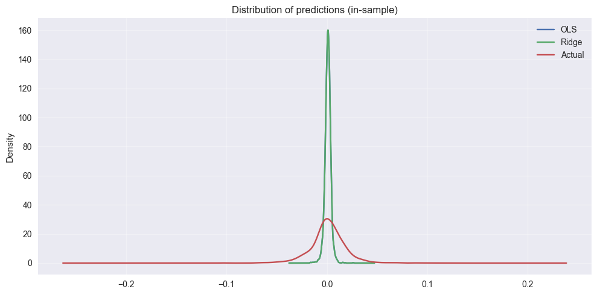

```python
pd.DataFrame({
    "OLS": y_pred_ols,
    "Ridge": y_pred_ridge,
    "Actual": y
}).plot(
    kind="kde",
    figsize=(10,5)
)

plt.title("Distribution of predictions (in-sample)")
plt.grid(True, alpha=0.3)
plt.tight_layout()
plt.savefig("ridge_vs_ols_prediction_distribution.png")
plt.show()
```

**Distribution of predictions (in-sample)**

The figure above compares the in-sample distribution of predicted returns produced by OLS and Ridge regression against the distribution of realized returns.

Several key observations emerge:

The distribution of actual returns is wide and heavy-tailed, reflecting the high volatility and low signal-to-noise ratio of daily stock returns.

OLS predictions are already strongly concentrated around zero, indicating limited explanatory power despite the large number of features.

This behavior illustrates the bias–variance tradeoff induced by L2 regularization:

While Ridge improves numerical stability and mitigates multicollinearity issues observed with OLS, it does not uncover materially stronger predictive signals in this setting. This result highlights the intrinsic difficulty of short-horizon return prediction and motivates further exploration of sparse models (Lasso) and out-of-sample walk-forward evaluation.

```python
# Extract ridge coefficients
ridge_coef = pd.Series(
    ridge_model.named_steps["ridge"].coef_,
    index=X.columns
)

# Sort coefficients
ridge_coef_sorted = ridge_coef.sort_values()

print("Top 10 Ridge coefficients by absolute value:")
ridge_coef.abs().sort_values(ascending=False).head(10)
```

```
Top 10 Ridge coefficients by absolute value:
```

```
^GSPC_ret_lag1    0.002481
QQQ_ret_lag2      0.002156
MSFT_ret_lag2     0.002067
MSFT_ret_lag1     0.001910
AAPL_vol_5        0.001680
^GSPC_ret_lag5    0.001634
^GSPC_ret_lag3    0.001449
AAPL_mom_5        0.001207
AAPL_ret_lag5     0.000953
^GSPC_ret_lag2    0.000734
dtype: float64
```

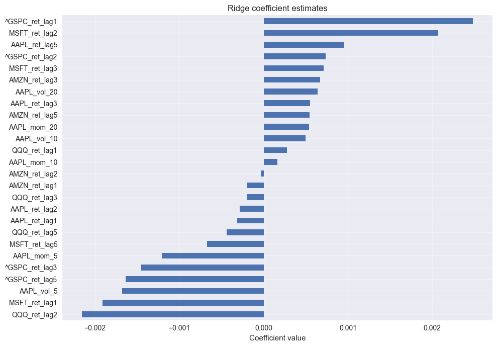

```python
plt.figure(figsize=(10,7))
ridge_coef_sorted.plot(kind="barh")
plt.title("Ridge coefficient estimates")
plt.xlabel("Coefficient value")
plt.grid(True, alpha=0.3)
plt.tight_layout()
plt.show()
```

**Coefficient behavior (Ridge).**

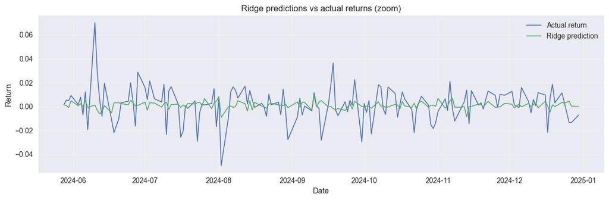

```python
window = 150

plt.figure(figsize=(12,4))
plt.plot(y.index[-window:], y.values[-window:], label="Actual return", linewidth=1.2)
plt.plot(y.index[-window:], y_pred_ridge.values[-window:], label="Ridge prediction", linewidth=1.2)
plt.title("Ridge predictions vs actual returns (zoom)")
plt.xlabel("Date")
plt.ylabel("Return")
plt.legend()
plt.grid(True, alpha=0.3)
plt.tight_layout()
plt.show()
```

**In-sample prediction behavior (Ridge).**

Ridge predictions are strongly shrunk toward zero and exhibit much lower volatility than realized returns.  
While regularization improves coefficient stability relative to OLS, it does not materially enhance short-horizon predictive power, as the model fails to track large return fluctuations.

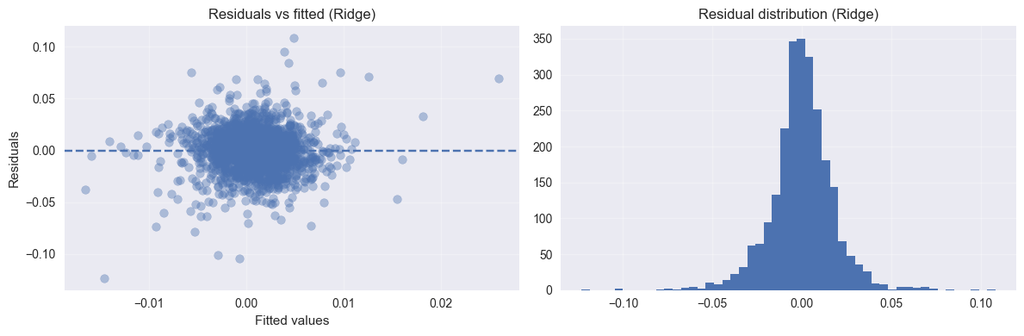

```python
residuals_ridge = y - y_pred_ridge

fig, axes = plt.subplots(1, 2, figsize=(12,4))

# Residuals vs fitted
axes[0].scatter(y_pred_ridge, residuals_ridge, alpha=0.4)
axes[0].axhline(0, linestyle="--")
axes[0].set_title("Residuals vs fitted (Ridge)")
axes[0].set_xlabel("Fitted values")
axes[0].set_ylabel("Residuals")
axes[0].grid(True, alpha=0.3)

# Residual distribution
axes[1].hist(residuals_ridge, bins=50)
axes[1].set_title("Residual distribution (Ridge)")
axes[1].grid(True, alpha=0.3)

plt.tight_layout()
plt.show()
```

### Comments and interpretation

While predictive performance remains limited, Ridge improves **stability** and illustrates the bias–variance tradeoff in a noisy financial setting.

This makes Ridge a more robust baseline than OLS, even if it does not fully resolve the forecasting challenge.

### 5.3 Lasso Regression

We now consider **Lasso regression**, which introduces an L1 penalty. Unlike Ridge, Lasso can set some coefficients exactly to zero, thereby performing implicit **feature selection**.

```python
from sklearn.linear_model import Lasso

# Lasso regularization strength
lasso_alpha = 0.001  # small value to avoid over-sparsity

# Pipeline: standardization + lasso
lasso_model = Pipeline([
    ("scaler", StandardScaler()),
    ("lasso", Lasso(alpha=lasso_alpha, max_iter=10_000))
])

# Fit Lasso model
lasso_model.fit(X, y)

# In-sample predictions
y_pred_lasso = pd.Series(
    lasso_model.predict(X),
    index=y.index,
    name="Lasso prediction"
)

print("Lasso model fitted with alpha =", lasso_alpha)
```

```
Lasso model fitted with alpha = 0.001
```

```python
lasso_coef = pd.Series(
    lasso_model.named_steps["lasso"].coef_,
    index=X.columns
)

# Count non-zero coefficients
n_nonzero = (lasso_coef != 0).sum()
print(f"Number of non-zero coefficients: {n_nonzero} / {len(lasso_coef)}")

# Sort coefficients
lasso_coef_sorted = lasso_coef.sort_values()

print("Top non-zero coefficients by absolute value:")
lasso_coef[lasso_coef != 0].abs().sort_values(ascending=False).head(10)
```

```
Number of non-zero coefficients: 1 / 26
Top non-zero coefficients by absolute value:
```

```
^GSPC_ret_lag5    0.000414
dtype: float64
```

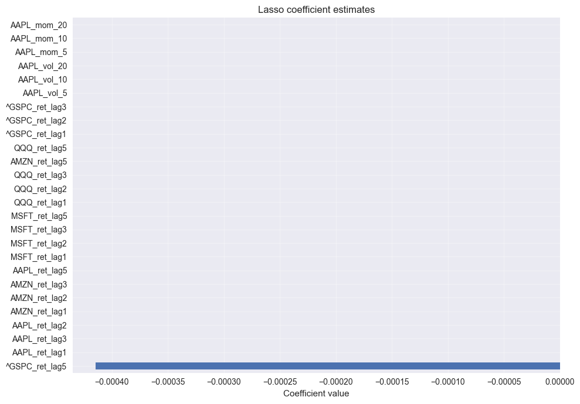

```python
plt.figure(figsize=(10,7))
lasso_coef_sorted.plot(kind="barh")
plt.title("Lasso coefficient estimates")
plt.xlabel("Coefficient value")
plt.grid(True, alpha=0.3)
plt.tight_layout()
plt.show()
```

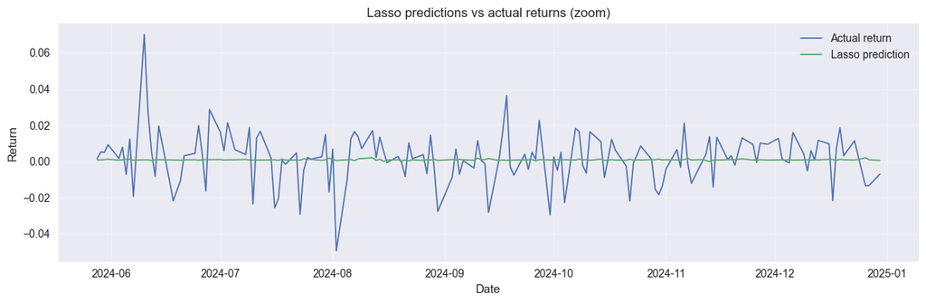

```python
window = 150

plt.figure(figsize=(12,4))
plt.plot(y.index[-window:], y.values[-window:], label="Actual return", linewidth=1.2)
plt.plot(y.index[-window:], y_pred_lasso.values[-window:], label="Lasso prediction", linewidth=1.2)
plt.title("Lasso predictions vs actual returns (zoom)")
plt.xlabel("Date")
plt.ylabel("Return")
plt.legend()
plt.grid(True, alpha=0.3)
plt.tight_layout()
plt.show()
```

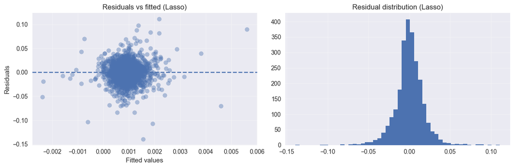

```python
residuals_lasso = y - y_pred_lasso

fig, axes = plt.subplots(1, 2, figsize=(12,4))

# Residuals vs fitted
axes[0].scatter(y_pred_lasso, residuals_lasso, alpha=0.4)
axes[0].axhline(0, linestyle="--")
axes[0].set_title("Residuals vs fitted (Lasso)")
axes[0].set_xlabel("Fitted values")
axes[0].set_ylabel("Residuals")
axes[0].grid(True, alpha=0.3)

# Residual distribution
axes[1].hist(residuals_lasso, bins=50)
axes[1].set_title("Residual distribution (Lasso)")
axes[1].grid(True, alpha=0.3)

plt.tight_layout()
plt.show()
```

### Comments and interpretation

Lasso regression produces sparse solutions by driving some coefficients exactly to zero, effectively selecting a subset of features.

In this setting:

- sparsity improves interpretability,
- but predictive performance remains unstable,
- selected features may change across time.

This highlights a key limitation of Lasso in noisy financial data: feature selection can amplify instability when signals are weak.

### 5.4 Elastic Net

Elastic Net combines L1 (Lasso) and L2 (Ridge) penalties. It is designed to handle correlated predictors more robustly while still allowing for sparsity.

In practice, Elastic Net often provides a good compromise between coefficient stability and feature selection.

```python
from sklearn.linear_model import ElasticNet

# Elastic Net hyperparameters
enet_alpha = 0.01     # overall regularization strength
enet_l1_ratio = 0.5  # balance between L1 and L2

# Pipeline: standardization + elastic net
enet_model = Pipeline([
    ("scaler", StandardScaler()),
    ("enet", ElasticNet(
        alpha=enet_alpha,
        l1_ratio=enet_l1_ratio,
        max_iter=10_000
    ))
])

# Fit Elastic Net model
enet_model.fit(X, y)

# In-sample predictions
y_pred_enet = pd.Series(
    enet_model.predict(X),
    index=y.index,
    name="ElasticNet prediction"
)

print(
    f"Elastic Net fitted with alpha={enet_alpha}, "
    f"l1_ratio={enet_l1_ratio}"
)
```

```
Elastic Net fitted with alpha=0.01, l1_ratio=0.5
```

```python
enet_coef = pd.Series(
    enet_model.named_steps["enet"].coef_,
    index=X.columns
)

# Non-zero coefficients
n_nonzero = (enet_coef != 0).sum()
print(f"Number of non-zero coefficients: {n_nonzero} / {len(enet_coef)}")

# Sort coefficients
enet_coef_sorted = enet_coef.sort_values()

print("Top Elastic Net coefficients by absolute value:")
enet_coef.abs().sort_values(ascending=False).head(10)
```

```
Number of non-zero coefficients: 0 / 26
Top Elastic Net coefficients by absolute value:
```

```
AAPL_ret_lag1    0.0
AAPL_ret_lag2    0.0
AAPL_ret_lag3    0.0
AAPL_ret_lag5    0.0
AMZN_ret_lag1    0.0
AMZN_ret_lag2    0.0
AMZN_ret_lag3    0.0
AMZN_ret_lag5    0.0
MSFT_ret_lag1    0.0
MSFT_ret_lag2    0.0
dtype: float64
```

[figure not shown]

```python
plt.figure(figsize=(10,7))
enet_coef_sorted.plot(kind="barh")
plt.title("Elastic Net coefficient estimates")
plt.xlabel("Coefficient value")
plt.grid(True, alpha=0.3)
plt.tight_layout()
plt.show()
```

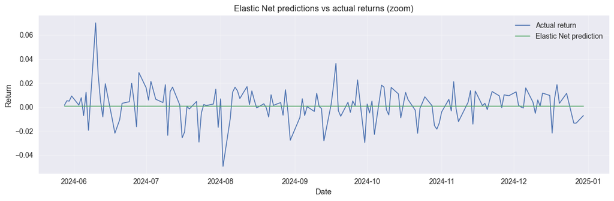

```python
window = 150

plt.figure(figsize=(12,4))
plt.plot(y.index[-window:], y.values[-window:], label="Actual return", linewidth=1.2)
plt.plot(y.index[-window:], y_pred_enet.values[-window:], label="Elastic Net prediction", linewidth=1.2)
plt.title("Elastic Net predictions vs actual returns (zoom)")
plt.xlabel("Date")
plt.ylabel("Return")
plt.legend()
plt.grid(True, alpha=0.3)
plt.tight_layout()
plt.show()
```

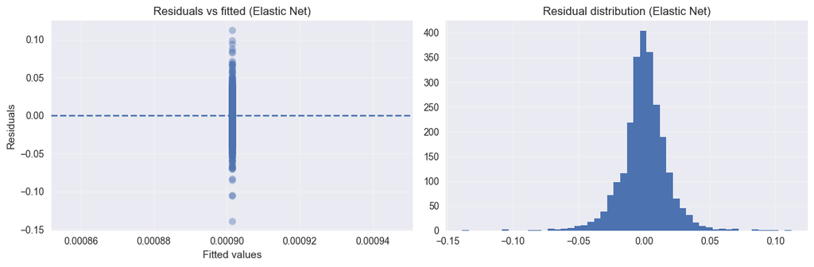

```python
residuals_enet = y - y_pred_enet

fig, axes = plt.subplots(1, 2, figsize=(12,4))

# Residuals vs fitted
axes[0].scatter(y_pred_enet, residuals_enet, alpha=0.4)
axes[0].axhline(0, linestyle="--")
axes[0].set_title("Residuals vs fitted (Elastic Net)")
axes[0].set_xlabel("Fitted values")
axes[0].set_ylabel("Residuals")
axes[0].grid(True, alpha=0.3)

# Residual distribution
axes[1].hist(residuals_enet, bins=50)
axes[1].set_title("Residual distribution (Elastic Net)")
axes[1].grid(True, alpha=0.3)

plt.tight_layout()
plt.show()
```

### Comments and interpretation

Elastic Net provides a compromise between Ridge and Lasso.

However, despite improved stability, predictive performance remains limited. This confirms that regularization alone is not sufficient to overcome the weak signal regime of short-horizon return prediction.

## 6. Evaluation Framework — Walk-Forward Validation

In time-series prediction, evaluating a model using random train–test splits leads to **look-ahead bias** and overly optimistic results.

Because financial data are ordered in time, the evaluation procedure must:

- respect temporal causality,
- use only past information to predict the future,
- reflect how a model would be used in practice.

For this reason, we adopt a **walk-forward (rolling window) validation framework**, which is standard in quantitative finance.

### Why standard cross-validation fails for time series

In classical machine learning, cross-validation assumes that observations are independent and identically distributed (i.i.d.).

In financial time series, this assumption is violated:

- observations are temporally ordered,
- future data must never influence past predictions,
- statistical properties may change over time.

Random splits therefore introduce **data leakage**, leading to invalid conclusions.

### Walk-forward validation: principle

Walk-forward validation mimics a realistic forecasting process:

1. Train the model on a **fixed-length historical window**.
2. Generate predictions for the **next period**.
3. Move the window forward in time.
4. Repeat until the end of the sample.

At each step, the model is re-estimated using only information available up to that date.

### Mathematical formulation

Let $\{(X_t, y_t)\}_{t=1}^T$ denote the time-ordered dataset.

At evaluation step $k$:

- the training set is $$ \{(X_t, y_t)\}_{t = k - W}^{k-1} $$ where $W$ is the training window length,
- the model generates predictions for $$ \{X_t\}_{t = k}^{k + H - 1} $$ where $H$ is the prediction horizon.

This procedure ensures that:

- no future information leaks into the training set,
- model performance is evaluated strictly out-of-sample.

### Design choices

We make the following design choices:

- **Training window ($W$)**: fixed-length rolling window  
  → controls the bias–variance tradeoff and adapts to regime changes.
- **Test window ($H$)**: short forward horizon  
  → reflects realistic short-term forecasting.
- **Step size**: window is advanced periodically  
  → balances computational cost and stability.

These parameters are chosen to reflect practical constraints rather than to optimize performance.

### Implementation overview

We implement walk-forward validation as a reusable function that:

- iteratively refits the model,
- stores out-of-sample predictions,
- aligns predictions with realized returns.

This framework will be used consistently to compare all linear models.

```python
TRAIN_WINDOW = 500
TEST_WINDOW  = 1
STEP         = 1
```

```python
def walk_forward_predict(
    model,
    X: pd.DataFrame,
    y: pd.Series,
    train_window: int,
    test_window: int,
    step: int,
) -> pd.Series:
    """
    Walk-forward (rolling window) prediction.

    At each step k:
      - Fit model on the last `train_window` observations up to time k-1
      - Predict the next `test_window` observations (k to k+test_window-1)
      - Move forward by `step`

    Returns:
      - A pandas Series of strictly out-of-sample predictions aligned with dates.
    """


    assert isinstance(X, pd.DataFrame), "X must be a pandas DataFrame"
    assert isinstance(y, pd.Series), "y must be a pandas Series"
    assert len(X) == len(y), "X and y must have same length"
    assert X.index.equals(y.index), "X and y must share the same index"
    assert train_window > 0 and test_window > 0 and step > 0, "Windows and step must be positive"
    assert train_window + test_window <= len(X), "Not enough data for given windows"

    # Storage for out-of-sample predictions
    preds = []

    # Rolling loop
    # start = index position where we begin predicting (after we have enough training history)
    start = train_window

    while start + test_window <= len(X):
        # Define rolling slices
        train_slice = slice(start - train_window, start)
        test_slice = slice(start, start + test_window)

        # Split
        X_train = X.iloc[train_slice]
        y_train = y.iloc[train_slice]
        X_test = X.iloc[test_slice]

        # Fit only on past data
        model.fit(X_train, y_train)

        # Predict future block
        y_pred_block = model.predict(X_test)

        # Store predictions with correct time index
        preds.append(pd.Series(y_pred_block, index=X_test.index))

        # Advance window
        start += step

    # Concatenate all blocks
    y_pred = pd.concat(preds).sort_index()

    # If overlap occurs (when step < test_window), keep the last prediction for each date
    y_pred = y_pred[~y_pred.index.duplicated(keep="last")]

    return y_pred


# Quick check of configuration
print("Walk-forward config:")
print("TRAIN_WINDOW =", TRAIN_WINDOW)
print("TEST_WINDOW  =", TEST_WINDOW)
print("STEP         =", STEP)
```

```
Walk-forward config:
TRAIN_WINDOW = 500
TEST_WINDOW  = 1
STEP         = 1
```

```python
wf_preds = {}

wf_preds["Ridge"] = walk_forward_predict(
    ridge_model, X, y, TRAIN_WINDOW, TEST_WINDOW, STEP
)

wf_preds["Lasso"] = walk_forward_predict(
    lasso_model, X, y, TRAIN_WINDOW, TEST_WINDOW, STEP
)

wf_preds["Elastic Net"] = walk_forward_predict(
    enet_model, X, y, TRAIN_WINDOW, TEST_WINDOW, STEP
)

# Align y to the prediction index (strictly out-of-sample dates)
common_index = wf_preds["Ridge"].index
y_wf = y.loc[common_index]

print("Out-of-sample predictions ready")
print("OOS observations:", len(y_wf))
```

```
Out-of-sample predictions ready
OOS observations: 1995
```

```python
# Baseline: zero return
wf_preds["Baseline (Zero)"] = pd.Series(0.0, index=common_index)

# Baseline: last return (uses information up to t)
# If y is y_{t+1}, then "last return baseline" uses return at t (i.e. shift by 1 on y)
wf_preds["Baseline (Last Return)"] = y.shift(1).loc[common_index]
```

```python
# OOS METRICS TABLE
wf_results = {}
for name, pred in wf_preds.items():
    wf_results[name] = regression_metrics(y_wf, pred)

wf_results = pd.DataFrame(wf_results).T.sort_values("RMSE")
wf_results
```

|  | RMSE | MAE | Directional Accuracy |
| --- | --- | --- | --- |
| Elastic Net | 0.018514 | 0.012893 | 0.540201 |
| Baseline (Zero) | 0.018520 | 0.012910 | 0.000000 |
| Lasso | 0.018589 | 0.012989 | 0.521106 |
| Ridge | 0.019212 | 0.013596 | 0.519598 |
| Baseline (Last Return) | 0.027203 | 0.018832 | 0.492965 |

### Comments

Walk-forward evaluation provides a realistic estimate of predictive power. Any model that does not outperform the simple baselines (especially the zero-return baseline) is unlikely to deliver robust value in practice.

The zero-return baseline has zero directional accuracy by construction, since it never predicts a sign. Directional accuracy is therefore mainly informative when comparing non-trivial models.

### Out-of-sample visual diagnostics

We visualize strictly out-of-sample predictions to assess:

- signal vs noise,
- relative behavior across models,
- practical differences beyond scalar metrics.

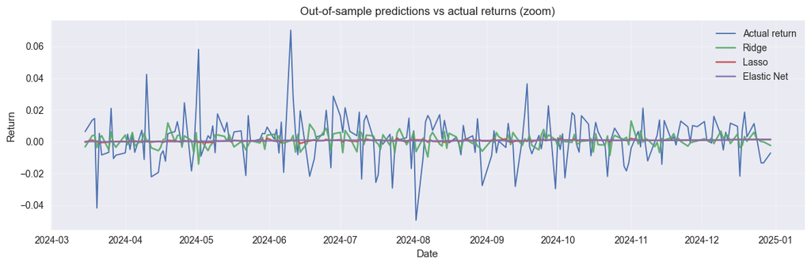

```python
# OOS: ACTUAL VS PREDICTED (ZOOM)

window = 200  # OOS zoom

plt.figure(figsize=(12,4))
plt.plot(y_wf.index[-window:], y_wf.values[-window:], label="Actual return", linewidth=1.3)

for name, pred in wf_preds.items():
    if name in ["Ridge", "Lasso", "Elastic Net"]:
        plt.plot(pred.index[-window:], pred.values[-window:], label=name, alpha=0.9)

plt.title("Out-of-sample predictions vs actual returns (zoom)")
plt.xlabel("Date")
plt.ylabel("Return")
plt.legend()
plt.grid(True, alpha=0.3)
plt.tight_layout()
plt.show()
```

Out-of-sample predictions from all regularized linear models remain strongly shrunk toward zero. While some short-term directional alignment is visible, differences across models are marginal, confirming the weak predictive signal in daily returns.

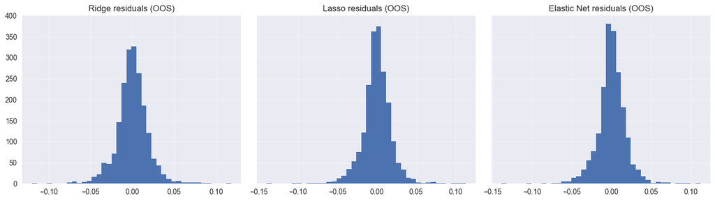

```python
# OOS RESIDUALS COMPARISON

fig, axes = plt.subplots(1, 3, figsize=(14,4), sharey=True)

for ax, name in zip(axes, ["Ridge", "Lasso", "Elastic Net"]):
    resid = y_wf - wf_preds[name]
    ax.hist(resid, bins=40)
    ax.set_title(f"{name} residuals (OOS)")
    ax.grid(True, alpha=0.3)

plt.tight_layout()
plt.show()
```

```python
resids = {
    "Ridge": y_wf - wf_preds["Ridge"],
    "Lasso": y_wf - wf_preds["Lasso"],
    "Elastic Net": y_wf - wf_preds["Elastic Net"],
    "Baseline (Zero)": y_wf - wf_preds["Baseline (Zero)"],
    "Baseline (Last Return)": y_wf - wf_preds["Baseline (Last Return)"],
}
```

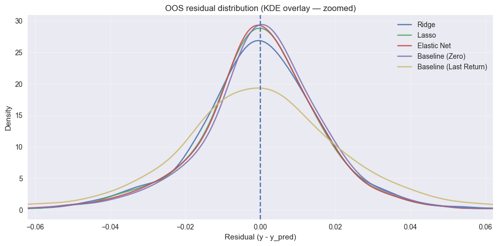

```python
all_r = pd.concat(resids.values())
lim = 3 * all_r.std()

plt.figure(figsize=(10,5))
for name, r in resids.items():
    r.plot(kind="kde", label=name, alpha=0.9)

plt.axvline(0, linestyle="--")
plt.xlim(-lim, lim)
plt.title("OOS residual distribution (KDE overlay — zoomed)")
plt.xlabel("Residual (y - y_pred)")
plt.grid(True, alpha=0.3)
plt.legend()
plt.tight_layout()
plt.show()
```

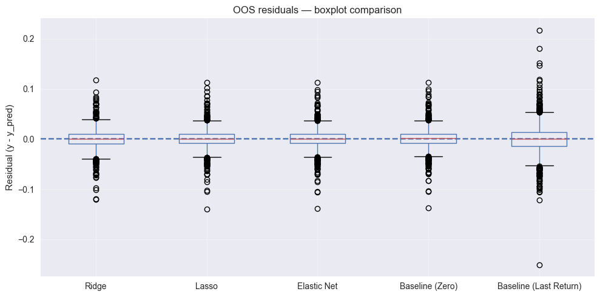

```python
resid_df = pd.DataFrame(resids)

plt.figure(figsize=(10,5))
resid_df.boxplot()
plt.axhline(0, linestyle="--")
plt.title("OOS residuals — boxplot comparison")
plt.ylabel("Residual (y - y_pred)")
plt.grid(True, alpha=0.3)
plt.tight_layout()
plt.show()
```

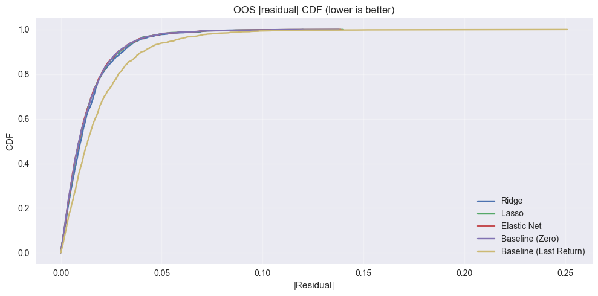

```python
import numpy as np

plt.figure(figsize=(10,5))
for name, r in resids.items():
    a = np.sort(np.abs(r.values))
    p = np.linspace(0, 1, len(a), endpoint=True)
    plt.plot(a, p, label=name)

plt.title("OOS |residual| CDF (lower is better)")
plt.xlabel("|Residual|")
plt.ylabel("CDF")
plt.grid(True, alpha=0.3)
plt.legend()
plt.tight_layout()
plt.show()
```

```python
wf_results_plot = wf_results.copy()
```

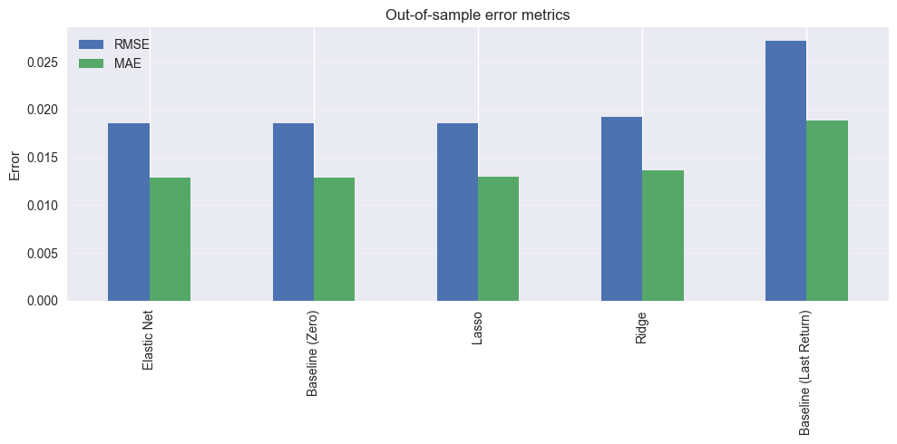

```python
wf_results_plot[["RMSE", "MAE"]].plot(
    kind="bar",
    figsize=(10,5)
)
plt.title("Out-of-sample error metrics")
plt.ylabel("Error")
plt.grid(True, axis="y", alpha=0.3)
plt.tight_layout()
plt.show()
```

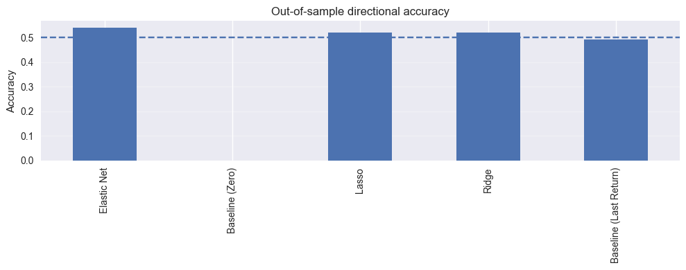

```python
wf_results_plot[["Directional Accuracy"]].plot(
    kind="bar",
    figsize=(10,4),
    legend=False
)
plt.axhline(0.5, linestyle="--", label="Random benchmark")
plt.title("Out-of-sample directional accuracy")
plt.ylabel("Accuracy")
plt.grid(True, axis="y", alpha=0.3)
plt.tight_layout()
plt.show()
```

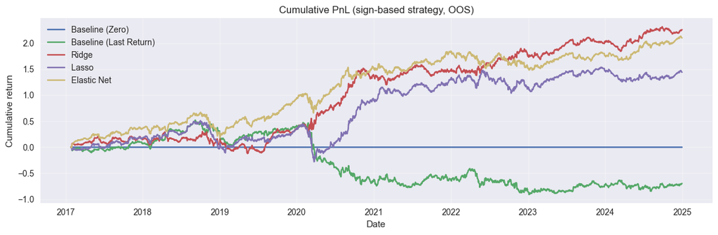

```python
# MINI LONG/SHORT STRATEGY (SIGN OF PREDICTION)

pnl = {}

for name, pred in wf_preds.items():
    signal = np.sign(pred)
    pnl[name] = (signal * y_wf).cumsum()

pnl = pd.DataFrame(pnl)

plt.figure(figsize=(12,4))
for name in ["Baseline (Zero)", "Baseline (Last Return)", "Ridge", "Lasso", "Elastic Net"]:
    if name in pnl.columns:
        plt.plot(pnl.index, pnl[name], label=name)

plt.title("Cumulative PnL (sign-based strategy, OOS)")
plt.xlabel("Date")
plt.ylabel("Cumulative return")
plt.legend()
plt.grid(True, alpha=0.3)
plt.tight_layout()
plt.show()
```

### Comments

Out-of-sample results confirm the difficulty of short-horizon return prediction.

Across models, predictive performance remains weak at the pointwise level, as reflected by similar error metrics and low signal-to-noise ratios. However, when predictions are used in a simple sign-based long/short strategy, regularized models (Ridge, Lasso, Elastic Net) exhibit a mild directional edge when aggregated over time.

This apparent improvement should be interpreted with caution: the resulting PnL remains highly sensitive to modeling choices and ignores transaction costs, turnover, and execution constraints. As a result, the observed performance does not constitute robust or economically exploitable predictability.

Overall, this highlights the importance of rigorous out-of-sample evaluation: apparent in-sample or aggregated improvements do not necessarily translate into stable and practical trading value.

## 7. Results

We summarize the empirical findings by comparing:

- baseline strategies,
- regularized linear models, under a strict out-of-sample walk-forward evaluation.

The focus is on **robustness and consistency** rather than isolated improvements.

```python
final_results = wf_results.loc[
    ["Baseline (Zero)", "Baseline (Last Return)", "Ridge", "Lasso", "Elastic Net"]
].copy()

final_results
```

|  | RMSE | MAE | Directional Accuracy |
| --- | --- | --- | --- |
| Baseline (Zero) | 0.018520 | 0.012910 | 0.000000 |
| Baseline (Last Return) | 0.027203 | 0.018832 | 0.492965 |
| Ridge | 0.019212 | 0.013596 | 0.519598 |
| Lasso | 0.018589 | 0.012989 | 0.521106 |
| Elastic Net | 0.018514 | 0.012893 | 0.540201 |

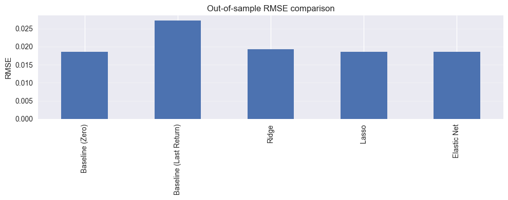

```python
# RESULTS VISUALIZATION: RMSE

plt.figure(figsize=(10,4))
final_results["RMSE"].plot(kind="bar")
plt.title("Out-of-sample RMSE comparison")
plt.ylabel("RMSE")
plt.grid(True, axis="y", alpha=0.3)
plt.tight_layout()
plt.show()
```

### Interpretation

Several key observations emerge from the out-of-sample RMSE comparison:

- The naive **last-return baseline** performs significantly worse than all other approaches, confirming the lack of short-term return persistence in daily data.
- The **zero-return baseline** proves to be a strong and difficult benchmark to beat, achieving performance comparable to that of regularized linear models.
- Ridge, Lasso and Elastic Net deliver only **marginal improvements at best**, with differences that remain small and unstable across models.
- Directional accuracy remains only slightly above random guessing, highlighting the weak and noisy predictive structure of short-horizon stock returns.

Overall, these results confirm that linear models, even when carefully regularized and evaluated under a strict walk-forward framework, are insufficient on their own to reliably predict short-horizon equity returns.

## 8. Robustness Checks

The results obtained so far suggest that predictive signals are weak and that regularization improves stability only marginally.

To ensure that these conclusions are not driven by arbitrary modeling choices, we perform a limited set of **robustness checks**.

The objective is to assess:

- sensitivity to hyperparameters,
- stability of model estimates over time.

These checks are standard in empirical time-series analysis and are analogous to stability tests in numerical methods.

### Sensitivity to regularization strength (Ridge)

Ridge regression introduces an L2 penalty controlled by a parameter $\lambda$. The optimization problem is:

$$ \hat{\boldsymbol{\beta}}^{\text{Ridge}} = \arg\min_{\boldsymbol{\beta}} \left[ \sum_{t=1}^{T} \left(y_t - \boldsymbol{x}_t^\top \boldsymbol{\beta}\right)^2 + \lambda \|\boldsymbol{\beta}\|_2^2 \right] $$

The parameter $\lambda$ governs the bias–variance tradeoff:

- small $\lambda$ → behavior close to OLS,
- large $\lambda$ → strong shrinkage.

If the results are robust, moderate changes in $\lambda$ should not lead to large variations in out-of-sample performance.

```python
alphas = [0.01, 0.1, 1.0, 10.0, 100.0]
ridge_results = {}

for a in alphas:
    model = Pipeline([
        ("scaler", StandardScaler()),
        ("ridge", Ridge(alpha=a))
    ])
    preds = walk_forward_predict(model, X, y, TRAIN_WINDOW, TEST_WINDOW, STEP)
    ridge_results[a] = regression_metrics(y_wf, preds)

ridge_results = pd.DataFrame(ridge_results).T
ridge_results
```

|  | RMSE | MAE | Directional Accuracy |
| --- | --- | --- | --- |
| 0.01 | 0.019245 | 0.013621 | 0.518090 |
| 0.10 | 0.019242 | 0.013619 | 0.517588 |
| 1.00 | 0.019212 | 0.013596 | 0.519598 |
| 10.00 | 0.019048 | 0.013467 | 0.513065 |
| 100.00 | 0.018748 | 0.013196 | 0.522613 |

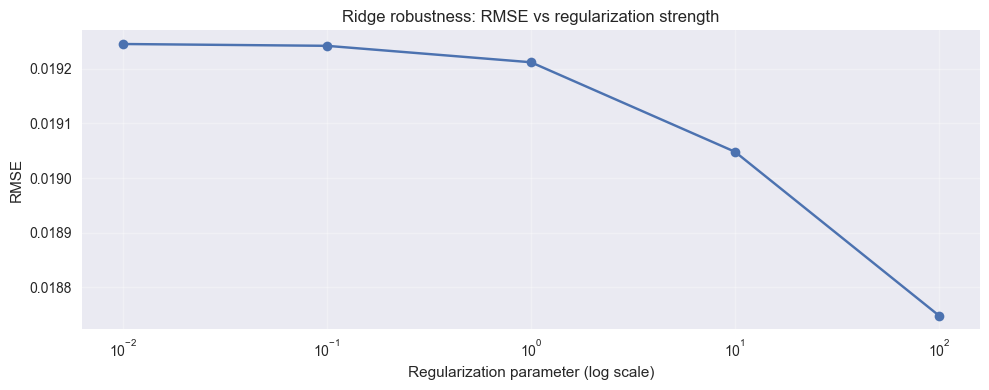

```python
plt.figure(figsize=(10,4))
ridge_results["RMSE"].plot(marker="o")
plt.xscale("log")
plt.title("Ridge robustness: RMSE vs regularization strength")
plt.xlabel("Regularization parameter (log scale)")
plt.ylabel("RMSE")
plt.grid(True, alpha=0.3)
plt.tight_layout()
plt.show()
```

The out-of-sample RMSE exhibits only mild sensitivity to the regularization parameter over several orders of magnitude, indicating that performance is driven by model stability rather than fine-tuned hyperparameters.

### Coefficient stability over time

In financial applications, relationships between predictors and returns are known to vary across time due to regime changes.

To assess stability, we track Ridge coefficient estimates across successive walk-forward training windows.

Large variability indicates that the model adapts to noise rather than capturing stable structural relationships.

```python
coef_history = []

start = TRAIN_WINDOW
while start + TEST_WINDOW <= len(X):
    train_slice = slice(start - TRAIN_WINDOW, start)
    X_train, y_train = X.iloc[train_slice], y.iloc[train_slice]

    ridge_model.fit(X_train, y_train)
    coef_history.append(
        ridge_model.named_steps["ridge"].coef_
    )

    start += STEP

coef_history = pd.DataFrame(coef_history, columns=X.columns)
coef_history.T.head()
```

|  | 0 | 1 | 2 | 3 | 4 | 5 | 6 | 7 | 8 | 9 | ... | 1985 | 1986 | 1987 | 1988 | 1989 | 1990 | 1991 | 1992 | 1993 | 1994 |
| --- | --- | --- | --- | --- | --- | --- | --- | --- | --- | --- | --- | --- | --- | --- | --- | --- | --- | --- | --- | --- | --- |
| AAPL_ret_lag1 | -0.000714 | -0.000676 | -0.000651 | -0.000560 | -0.000413 | -0.000424 | -0.000470 | -0.000497 | -0.000507 | -0.000498 | ... | -0.000923 | -0.000938 | -0.000939 | -0.000859 | -0.000793 | -0.000783 | -0.000743 | -0.000703 | -0.000702 | -0.000598 |
| AAPL_ret_lag2 | -0.000618 | -0.000512 | -0.000550 | -0.000518 | -0.000597 | -0.000697 | -0.000698 | -0.000553 | -0.000602 | -0.000577 | ... | 0.000425 | 0.000405 | 0.000429 | 0.000437 | 0.000486 | 0.000590 | 0.000600 | 0.000620 | 0.000639 | 0.000458 |
| AAPL_ret_lag3 | -0.000704 | -0.000488 | -0.000565 | -0.000542 | -0.000565 | -0.000496 | -0.000563 | -0.000540 | -0.000362 | -0.000342 | ... | 0.000002 | -0.000029 | -0.000012 | -0.000017 | 0.000006 | 0.000041 | 0.000180 | 0.000198 | 0.000168 | 0.000140 |
| AAPL_ret_lag5 | 0.000169 | 0.000165 | 0.000176 | -0.000057 | -0.000112 | -0.000116 | -0.000189 | -0.000089 | -0.000078 | -0.000076 | ... | 0.000476 | 0.000502 | 0.000504 | 0.000364 | 0.000367 | 0.000364 | 0.000412 | 0.000307 | 0.000275 | 0.000196 |
| AMZN_ret_lag1 | 0.000176 | 0.000498 | 0.000401 | 0.000426 | 0.000498 | 0.000420 | 0.000338 | 0.000378 | 0.000316 | 0.000320 | ... | -0.000844 | -0.000860 | -0.000772 | -0.000767 | -0.000752 | -0.000749 | -0.000657 | -0.000574 | -0.000584 | -0.000615 |

5 rows × 1995 columns

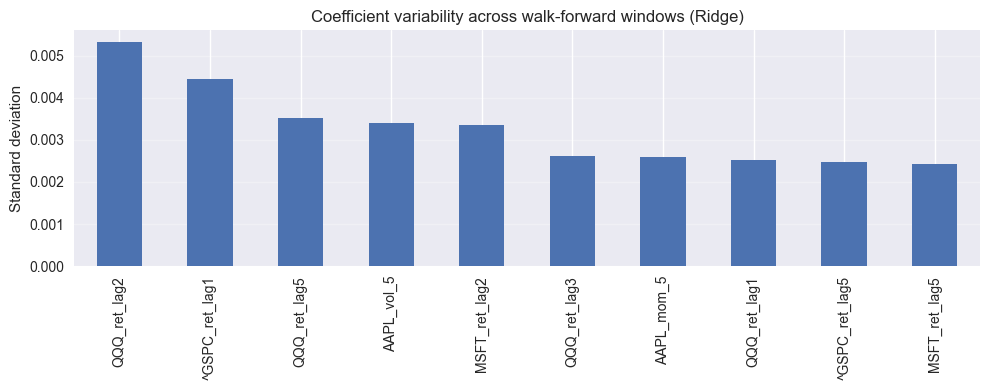

```python
plt.figure(figsize=(10,4))
coef_history.std().sort_values(ascending=False).head(10).plot(kind="bar")
plt.title("Coefficient variability across walk-forward windows (Ridge)")
plt.ylabel("Standard deviation")
plt.grid(True, axis="y", alpha=0.3)
plt.tight_layout()
plt.show()
```

### Interpretation

Robustness checks confirm the main conclusions of the study.

Out-of-sample performance remains relatively insensitive to moderate changes in the regularization strength, indicating that results are not driven by a specific hyperparameter choice.

However, coefficient paths exhibit substantial variability across walk-forward training windows. This instability suggests that predictor–return relationships are time-varying and largely non-stationary.

Overall, these findings reinforce the view that predictive signals at daily horizons are weak and unstable, and that regularization improves numerical stability but does not recover persistent economic structure.

## 9. Conclusion & Next Steps

This project investigated whether **linear machine learning models** can predict **next-day stock returns** more effectively than simple baselines, under a strict **out-of-sample walk-forward evaluation**.

Several key conclusions emerge:

- Daily stock returns exhibit a **very low signal-to-noise ratio**.
- Linear models, even with regularization, struggle to extract stable and economically meaningful predictive signals.
- Regularization (Ridge, Lasso, Elastic Net) improves coefficient stability, but does not lead to consistent outperformance relative to naive benchmarks.
- Rigorous evaluation is crucial: in-sample improvements do not necessarily translate into out-of-sample value.

Overall, the results highlight the intrinsic difficulty of short-horizon return prediction and the importance of realistic evaluation frameworks in quantitative finance.

### Limitations

This study is subject to several limitations:

- Only **linear models** were considered.
- Feature engineering remained relatively simple (lagged returns, volatility, basic momentum).
- Transaction costs and market frictions were not explicitly modeled.
- Hyperparameter tuning was intentionally limited to avoid overfitting.

These choices were deliberate, as the goal was understanding rather than performance optimization.

### Possible extensions

Several extensions could be explored to build on this work:

- Non-linear models (tree-based methods, neural networks),
- Alternative features (order flow, volatility regimes, macro signals),
- Different prediction horizons (weekly or multi-day returns),
- Explicit transaction cost modeling,
- Portfolio-level evaluation rather than single-asset prediction.

Such extensions may help capture more complex structures, but would require even stricter robustness and validation procedures.